# Bayes Statistics

## Примеры использования постериоров

```r
library(tidybayes)
```

```r
library(broom) # for tidy model summaries
library(languageR) # for the english dataset
library(patchwork) # for plotting
```

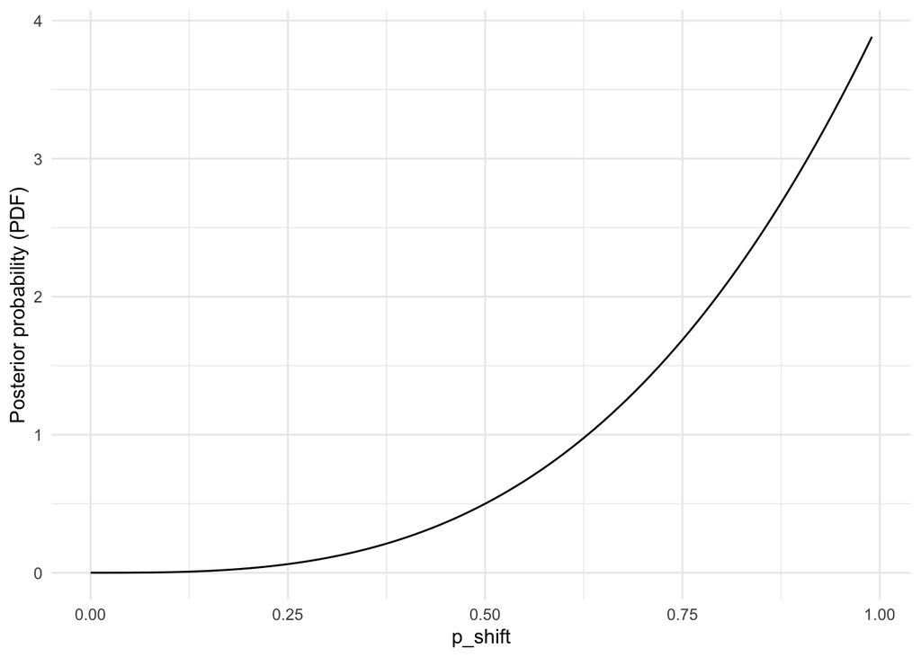

```r
#set up a vector of p=0...1
p_vec <- seq(0.0001,0.9999, by=0.01)

data.frame(p=p_vec, post=dbeta(p_vec, 4, 1)) %>%
  ggplot(aes(x=p_vec, y=post)) +
  geom_line() +
  xlab("p_shift") +
  ylab("Posterior probability (PDF)")
```

Можно было бы просто вычислить медиану, моду и т. д. для этой кривой, однако на практике мы почти всегда работаем с выборками из апостериорного распределения (как правило, полученными из обученной модели).

```r
## take 1000 samples
samples_1 <- rbeta(n=10000, 4, 1)
```

Для модели m31 мы будем использовать данные `diatones` из первых 20 наблюдений с прайором Beta(1, 1).

```r
diatones_m31<-
  brm(data = diatones[1:20,],
      family = binomial(link = "identity"),
      stress_shifted | trials(1) ~ 0 + Intercept,
      prior(beta(1, 1), class = b, lb = 0, ub = 1),
      file='models/diatones_m31.brm'
  )
diatones_m31
```

```
##  Family: binomial
##   Links: mu = identity
## Formula: stress_shifted | trials(1) ~ 0 + Intercept
##    Data: diatones[1:20, ] (Number of observations: 20)
##   Draws: 4 chains, each with iter = 2000; warmup = 1000; thin = 1;
##          total post-warmup draws = 4000
##
## Regression Coefficients:
##           Estimate Est.Error l-95% CI u-95% CI Rhat Bulk_ESS Tail_ESS
## Intercept     0.32      0.09     0.16     0.53 1.00     1734     1896
##
## Draws were sampled using sampling(NUTS). For each parameter, Bulk_ESS
## and Tail_ESS are effective sample size measures, and Rhat is the potential
## scale reduction factor on split chains (at convergence, Rhat = 1).
```

Модель будет записана в папку models, и при следующих вызовах `brm()` будет загружать ее из файла. Это полезно для вычислительно сложных и долгих в обучении моделей. Чтобы снова обучить модель, сотрите файл с диска.

Создадим выборки на основе постериора с помощью функции `spread_draws()` пакета `tidybayes`.

```r
diatones_m31_draws <- diatones_m31 %>% spread_draws(b_Intercept)
```

Функция `spread_draws(a)` форматирует выборку из апостериорного распределения для параметром(ами) `a` в виде тиббла в tidy формате, предназначенном для последующей обработки или визуализации; при этом доступно множество готовых процедур (см. [примеры](https://mjskay.github.io/tidybayes/articles/tidy-brms.html)). В нашем случае `diatones_m31_draws` содержит по одной строке на каждую выборку, полученную после этапа «разогрева» (warmup), — итого 4000 строк.

Построим график апостериорного распределения на основе этих выборок, используя функцию `stat_slab()` из пакета `tidybayes`:

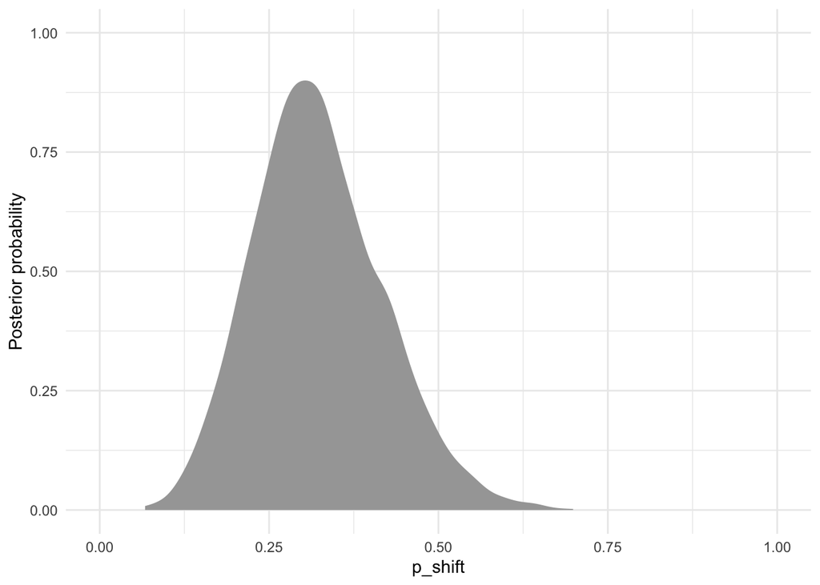

```r
diatones_m31_draws %>%
  ggplot(aes(x = b_Intercept)) +
  stat_slab()+ ## one way to visualize posterior; could also e.g. use a histogram
  xlab("p_shift")+
  ylab("Posterior probability") +
  xlim(0,1)
```

Сохраним выборки p_{shift} в виде отдельного вектора для удобства будущих операций.

```r
samples_2 <- diatones_m31_draws$b_Intercept
```